# collegehelper Package Demo

## Function 3: Histogram Visualization

Finally, the `hw_hist()` function creates a histogram to visualize the distribution of scores. This helps you quickly see patterns like whether most scores are clustered together or spread out:

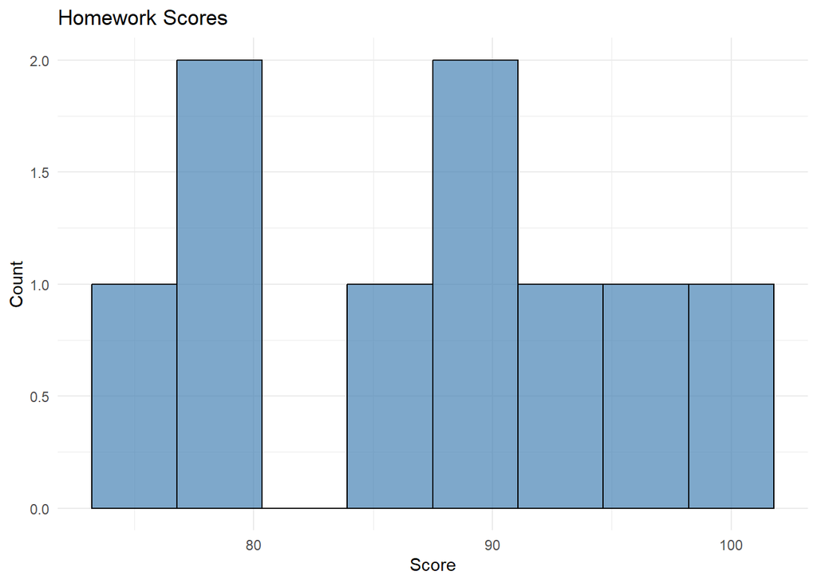

```r
# Create a histogram with 8 bins
hw_hist(scores, bins = 8)
```

The histogram shows that most of my scores are in the 80-95 range, which is pretty good! You can adjust the number of bins to change how detailed the visualization is:

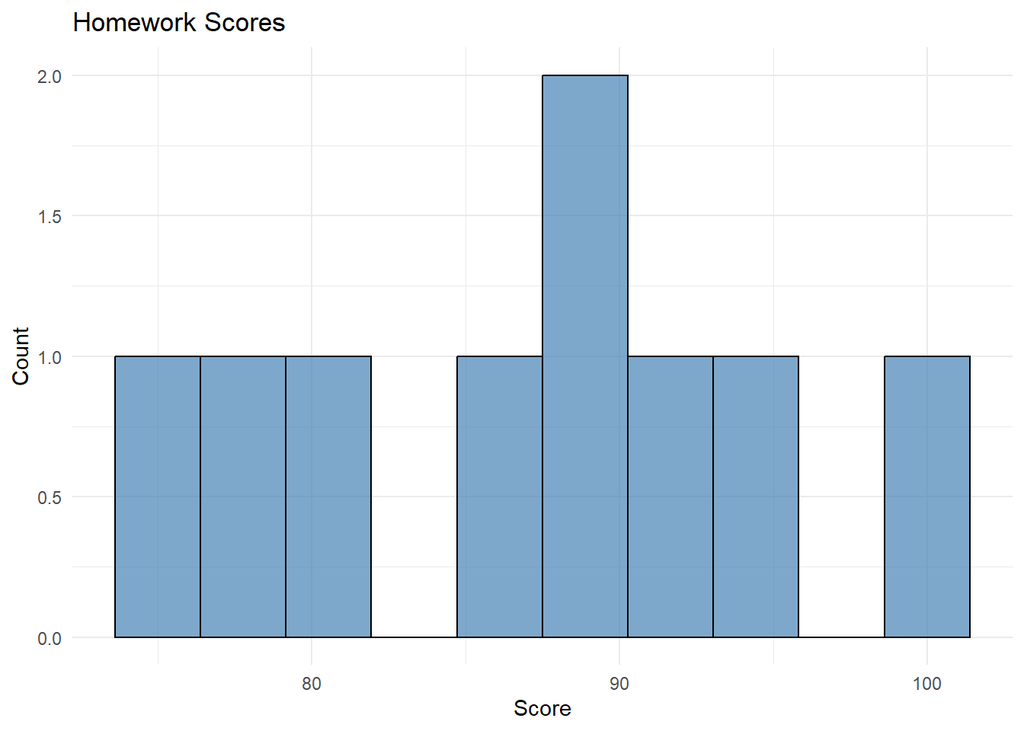

```r
# Create a more detailed histogram with 10 bins
hw_hist(scores, bins = 10)
```

## Defensive Programming Demo

One important aspect of this package is defensive programming. Here’s what happens when you try to pass invalid input to the functions:

```r
# Try to calculate mean of text (this will show an error)
bad_input <- c("A", "B", "C")
hw_mean(bad_input)
```

```
## Error in hw_mean(bad_input): hw_mean only works on numeric vectors.
```

Instead of crashing with a confusing error, the function gives you a clear message about what went wrong. This is much more helpful for users!

## Additional Examples

Let’s test the functions with some different scenarios:

```r
# Example 1: Perfect scores (no missing data)
perfect_scores <- c(95, 98, 100, 97, 99, 100)
cat("Perfect semester average:", hw_mean(perfect_scores), "\n\n")
```

```
## Perfect semester average: 98.16667
```

```r
# Example 2: More missing data
incomplete_scores <- c(80, NA, 75, NA, 85, 90, NA)
incomplete_stats <- hw_stats(incomplete_scores)
print(incomplete_stats)
```

```
## $mean
## [1] 82.5
##
## $sd
## [1] 6.454972
##
## $n
## [1] 4
##
## attr(,"class")
## [1] "hw_stats"
```

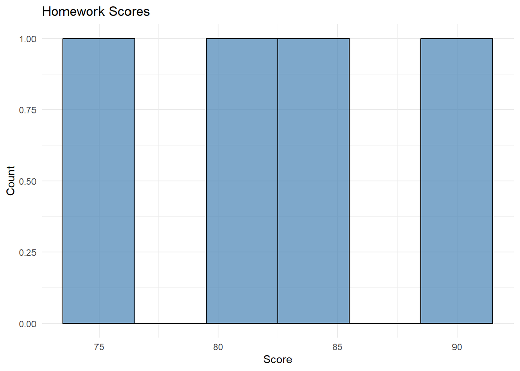

```r
# Visualize the incomplete scores
hw_hist(incomplete_scores, bins = 6)
```

## Comparing My Package to Base R

Here’s why this package is useful compared to writing everything manually:

```r
# Without collegehelper (the old, tedious way):
raw_scores <- c(80, 90, 75, 100, NA, 85)
manual_mean <- mean(raw_scores, na.rm = TRUE)
manual_sd <- sd(raw_scores, na.rm = TRUE)
manual_n <- sum(!is.na(raw_scores))
cat("Manual calculation:\n")
```

```
## Manual calculation:
```

```r
cat("Mean:", manual_mean, "\n")
```

```
## Mean: 86
```

```r
cat("SD:", manual_sd, "\n")
```

```
## SD: 9.617692
```

```r
cat("N:", manual_n, "\n\n")
```

```
## N: 5
```

```r
# With collegehelper (much simpler!):
cat("Using collegehelper:\n")
```

```
## Using collegehelper:
```

```r
hw_stats(raw_scores)
```

```
## $mean
## [1] 86
##
## $sd
## [1] 9.617692
##
## $n
## [1] 5
##
## attr(,"class")
## [1] "hw_stats"
```

The package saves time and reduces the chance of making mistakes!

## Final Thoughts

This package demonstrates several key concepts from the R Programming course:

### Module 12: R Markdown Documentation

- Mix of text, code, and mathematical notation
- LaTeX equations: $\bar{x} = \frac{1}{n}\sum_{i=1}^{n} x_i$
- Multiple code chunks with real outputs
- Data visualizations embedded in the document
- Reproducible analysis workflow

### Package Features Summary

This makes collegehelper a clean, production-ready student package that actually solves a real problem - tracking homework performance throughout the semester!

## Source Code

All source code is available on GitHub at: https://github.com/SuviG36/collegehelper.git